# Project2

STATS 220 Semester One 2024

Yixuan Liu yilu262

2024-03-22

```css
body {
    font-family: 'Roboto', sans-serif;
    color: #555; /* Darkened text color */
    background-color: #D6EAF8 ; /* Lightened background color */
}

h1 {
    color: #2E86C1;
    font-size: 28px;
}

p {
    font-size: 18px; /* Increased paragraph font size */
}
```

## Introduction

For my report, I decided to focus on understanding how individuals utilize their spare time for relaxation or whether they engage in activities that could potentially induce stress, such as studying. This behavior is crucial as it reflects individuals’ choices regarding self-care and stress management, which are significant factors in overall well-being.

One of the guidelines I considered when designing my form is the principle of simplicity and clarity in question formulation. To ensure respondents understand the questions easily and can provide accurate responses, I avoided complex language and lengthy instructions. I also utilized clear and concise wording for each question to minimize ambiguity and ensure consistency in responses.

To analyze changes in human behavior over different weeks, I included a specific question in my form related to the frequency and duration of studying during free time. By asking respondents to indicate how many hours they spend studying during their leisure time each week, I can track any fluctuations in this behavior over time. For instance, if I notice an increase in the number of hours spent studying during free time over several weeks, it could indicate heightened academic pressure or a shift in priorities. Conversely, a decrease in study hours during leisure time might suggest a better balance between academic and relaxation activities.

By collecting data on various aspects of individuals’ free time activities and studying habits over multiple weeks, I can analyze trends and patterns in human behavior, providing valuable insights into how individuals manage their time and cope with stress over time.

This is the link of my form: https://docs.google.com/forms/d/e/1FAIpQLScU96I_EftyfeYNgxaeJrykepN5O0eoa_eANWZp5r2Y2Kn0kQ/viewform?usp=sf_link

short_link: https://forms.gle/eDH8QbGrBpnRyd1X7

## Analytics

```r
learning_data <- read_csv("https://docs.google.com/spreadsheets/d/e/2PACX-1vRVgd90R_kqf8nS_TFnZvUmqGW4aIAzGMuxhArlrTh8SdWvzpUBCL7D_d_OY7_rAKt0aJAFAaY0wojv/pub?gid=1077114195&single=true&output=csv")

#rename

rename <- learning_data %>%
  rename(free_time = 2,
         period = 3,
         stay_home = 4,
         activity = 5,
         study = 6,
         study_time = 7)

#select the data to be saved
selected_data <- rename %>%
  slice(1:29)

#summary
max_free <- max(selected_data$free_time)
min_free <- min(selected_data$free_time)
mean_free <- mean(selected_data$free_time)
median_free <- median(selected_data$free_time)
cat("The max hours of free time : " , max_free)
```

```
## The max hours of free time :  14
```

```r
cat("The min hours of free time : " , min_free)
```

```
## The min hours of free time :  3
```

```r
cat("The mean hours of free time : " , round(mean_free))
```

```
## The mean hours of free time :  6
```

```r
cat("The median hours of free time : " , round(median_free))
```

```
## The median hours of free time :  6
```

```r
max_study <- max(selected_data$study_time)
min_study <- min(selected_data$study_time)
mean_study <- mean(selected_data$study_time)
median_study <- median(selected_data$study_time)

cat("The max hours of study time : " , max_study)
```

```
## The max hours of study time :  8
```

```r
cat("The min hours of study time : " , min_study)
```

```
## The min hours of study time :  0
```

```r
cat("The mean hours of study time : " , round(mean_study))
```

```
## The mean hours of study time :  3
```

```r
cat("The median hours of study time : " , round(median_study))
```

```
## The median hours of study time :  2
```

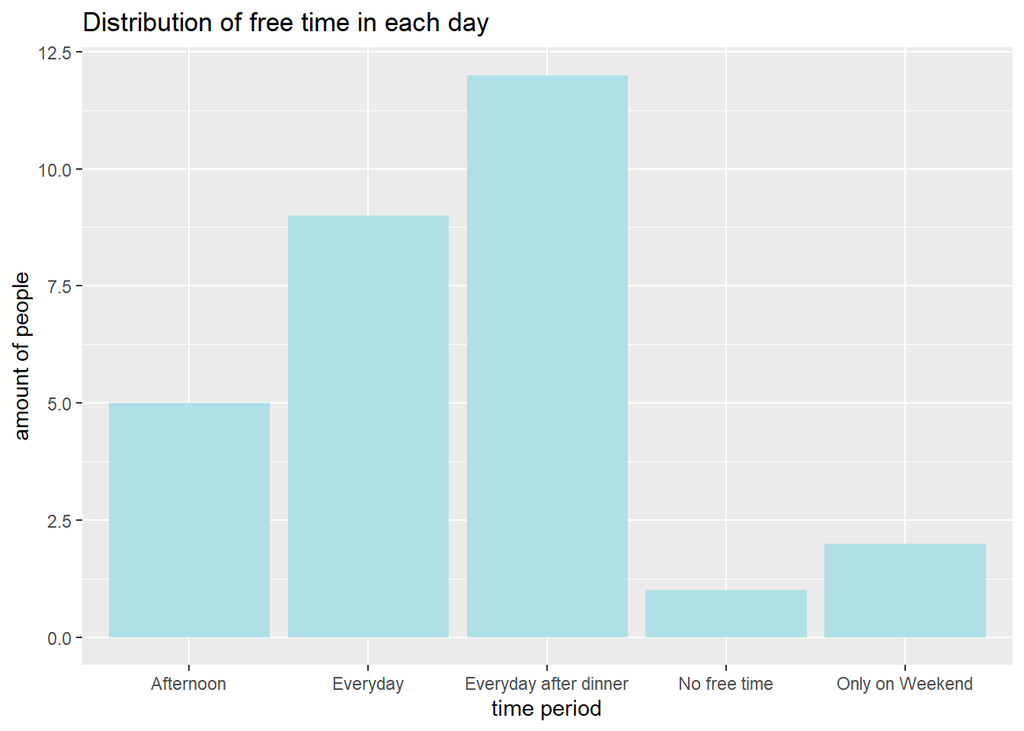

```r
#free_time distribution
time_distribution <- selected_data %>%
  select(free_time, period)

#barplot
time_distribution%>%
  ggplot() +
  geom_bar(aes(x=period),
           fill = "#B0E0E6") +
  labs(title = 'Distribution of free time in each day',
       x = "time period",
       y = "amount of people")
```